# greedy 2

Miguel Miní

31/10/2020

## Structural Argument

La idea de este enfoque está basado en observaciones que podemos hacer sobre determinadas estructuras que puede tener un problema para llegar a un resultado, Nuestros agoritos serán creados de tal forma que cumplan alguna restricción y luego probar que no existe algoritmo mejor que no cumpla ta restricción.

## Scheduling All Intervals (Interval Partitioning)

Una forma de generalizar el Interval Scheduling problem podría ser: nosotros debemos aceptar todos los intervalos y dividirlos en grupos de tal forma que cada grupo sea compatible, ¿Cuál es la menor cantidad de grupos que podemos lograr?

Por ejemplo, supongamos que cada rango corresponde para una clase que necesitamos de asignar a un salón de clases en un determinado intervalo de tiempo. Deseamos satisfacer esto usando la menor cantidad de salones de clases.

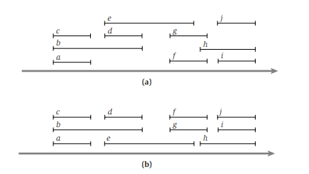

#### Afirmación:

- Dado un conjunto de intervalos, el mínimo número de filas en el Interval Partitinoning problem es al menos la profundiad del conjunto de intervalos.

nota: la profundidad de un conjunto de intervalos es igual a la máxima cantidad de intervalos que se sobrelapan dos a dos.

Prueba: Supngamos que el conjunto de intervalos tiene una profundidad de $d$, y sea $I_1, \dots, ~I_d$ un conjunto de intervalos que pasan a través de un único punto sobre la línea del tiempo. Entonces cada uno de los intervalos debe ser asignado a una fila diferente, tal que se necesita al menos $d$ filas.

Tenemos ahora dos preguntas, que están muy intimamente relacionada. Primero, ¿podemos diseñar un algoritmo eficiente que asigne todos los intervalos usando el mínimo número posible de filas? Segundo, ¿Existe una manera de siempre asignar usando un número de filas igual a la profundidad? En efecto, una respuesta positiva para la segunda pregunta nos dice que el único obstaculo para particionar intervalos es localizar un conjunto de intervalos todos apilados sobre un único punto. No es claramente inmediato que exista otra restricción que pueda hacer que empeore el número de filar a utilizar.

Ahora diseñamos un algoritmo greedy que asigne todos los intervalos usando un número de filar igual para la profundidad. Esto inmediatamente implica la optimalidad del algoritmo. El análisis de nuestro algoritmo debería por tanto ilustrar otro enfoque general para probar optimalidad: uno encuentra un simple “structural” cota que asegura que toda posible solución debería tener al menos un cierto valor y entonces uno ve que el algoritmo en consideración siempre optiene esta cota.

### Diseñando el algoritmo

Sea $d$ la profundidad del conjunto de intervalos; nosotros vemos como asignar una etiqueta a cadaintervalo, donde las etiquetas pertenecen al conjunto $\{1,~2,~3, ~\dots,~d\}$, y la asignación tiene la propiedad que intervalos sobrelapados tienen etiquetas con distinto número. Esto nos daría la solución deseada, ya que nosotros podemos interpretar cada número como el nombre del recurso, y la etiqueta de cada intervalo como el nombre del recurso que fue asignado.

El algoritmo está basado en una estrategia greedy que ordenar los intervalos por su tiempo de inicio. nosotros recorremos los intervalos in este orden, y tratamos de asignar a cada intervalo que vamos encontrando una etiqueta que no tiene asignado a cualquier intervalo anterior que sobrelapa con este. especificamente, tenemos la siguiente descripción:

```
Ordenar los intervalos por su tiempo de inicio,
en caso de empate seleccionar arbitrariamente

Sea I_1, I_2, ..., I_n los intervalos en este orden

Para j = 1, 2, ..., n

  Para cada intervalo I_i que precede I_j en el orden y
  que overlapa este, excluir las etiquetas de I_i en
  esta consideración

  Si existe una etiqueta en {1, 2, ..., d} que no ha sido excluida entonces
    asignar a I_j
  sino
    dejar I_j sin etiqueta
```

### Implementación eficiente en C++: $O(n \log n)$

```cpp
struct Interval {
  int l, r, color;
};

sort(R.begin(), R.end(), [](Interval p, Interval q) {
  return p.l < q.l;
});

multiset<pair<int, int>> s;
int d = 0;
for (auto r : R) {
  auto q = prev(s.upper_bound({r.first, 1e9}));
  if (q != s.end()) {
    s.erase(q);
    s.insert({r.second, q->second});
  } else {
    s.insert({r.second, ++d});
  }
}
```

### Analizando el algoritmo podemos afirmar los siguiente.

- **Si nosotros usamos el algoritmo greedy anterior, a todo intervalo se le debería asignar una etiqueta, y dos intervalos sobrelapados no deberían tener la misma etiqueta**

Prueba: Primero debemos argüir que no hay dos intervalos que terminen con la misma etiqueta. Consideramos uno de los intervalos $I_j$, y suponemos que estos son $t$ intervalos ordenados antes y que se sobrelapan con este. Estos $t$ intervalos, junto con el $I_j$, forman un conjunto de $t + 1$ intervalos tal que todos pasan por un punto en común sobre la línea de tiempo (llamado, el inicio del intervalos $I_j$), y así $t + 1 \le d$, por tanto $t \le d - 1$. De esto se sigue que al menos uno de las $d$ etiquetas no está excluida por este conjunto de t intervalos, y así existe una etiqueta que puede ser asignada a $I_j$.

Además nosotros podemos afirmar que dos intervalos que se sobrelapan no son asignados a la misma etiqueta. pues, si consideramos cualesquiera dos intervalos $I_1$ e $I_2$ que se sobrelapan, y suponamos $I_1$ precede a $I_2$ en el orden. Entonces cuando $I_2$ es considerado por el algoritmo, $I_1$ está en el conjunto de intervalos cuales etiquetas han sido exlucidas en la consideración; Consecuentemente, el algoritmo no debería asignar para $I_2$ a etiqueta asignada para $I_1$.

### Concluimos:

- El algoritmo greedy de arriba asigna todo intervalo a un recurso, usando un número de recursos igual a la profundidad de los intervalos. Esto es el número óptimo de recursos que pueden ser asignados.

## Contest

- [contest 1](https://vjudge.net/contest/405737)
- [contest 2](https://vjudge.net/contest/405738)

## Problemas que no se pudieron incluir

- skyscaping